# Computational Astrophysics 23-24

## Project track: Collisionless N-body simulations

### Project-3: Tidal disruptions of a Plummer model

# I Miloncini

| Last Name | First Name | Student Number |
| --- | --- | --- |
| Bertinelli | Gabriele | 2103359 |
| Bonato | Diego | 2091250 |
| Di Prima | Giacomo | 2086992 |
| Viterbo | Giuseppe | 2086516 |

# Part 1 - Optimization and parallelization

## The N-body Problem

The N-body problem refers to the challenge of predicting the movement of a collection of celestial bodies that are gravitationally interacting. This issue holds significant relevance in the field of astrophysics due to its wide application across various astrophysical contexts and scales.  
The N-body problem is an extension of Newton's law of universal gravitation problem.

The acceleration of the body $i$ due to all the other bodies $j$ is expressed by $$ \begin{equation*} \frac{ d^2 \vec{x}_i } {dt^2} = - G \sum^N_{j=1, j\neq i} m_j \frac{ \vec{x}_i - \vec{x}_j }{ | \vec{x}_i - \vec{x}_j |^3 } . \end{equation*} $$

Each N-body system possesses six constants of motion, comprising the position and velocity of the center of mass, along with four integrals of motion encompassing energy and the three components of angular momentum.

While an analytic solution exists for N=2, extending it to a general N-body system remains elusive. Adding just a third particle increases the unknowns to 18, necessitating constraints for an analytic solution, which is only feasible for specific cases like the circular restricted three-body problem.  
Numerical methods are indispensable for integrating the system's differential equations. Notably, the problem's numerical complexity scales at O(N^2), posing a significant hurdle in system modeling due to rapid growth with increasing N.

## The Fireworks Python Package

Fireworks is a Python library that contains tools to initialize and evolve N-body systems and it can be used to simulate collisionless systems, collisional systems and orbit integration. It also contains some other useful tools as `pyfalcon` and `TSUNAMI`.  
Fireworks contains the following submodules:

- `particles`: it contains the class `Particles` in which all the information about the particles can be stored (position, velocity, mass), and it provides useful tools to retrieve physical quantities of the system (e.g. CoM quantities, potential, kinetic and total energies);
- `ic`: it contains functions through which initial conditions can be generated. The module contains two functions: `ic_random_normal`, which draws initial conditions from a normal distribution, and `ic_two_body`, which generates initial conditions for the case of a two-body system;
- `Nbodylib`: it contains functions to estimate the gravitational forces and accelerations. It is divided into other four modules:
  - `dynamics`: it contains functions to estimate accelerations due to gravitational forces. `acceleration_pyfalcon`, used in our work, is a function of this module. In this module we can find our ad hoc built acceleration estimate functions: `acceleration_direct` and `acceleration_direct_vectorized`. The first computes gravitational acceleration between particles using a direct method (i.e. for loops), while the latter leverages the broadcasting operations of `numpy.array`.
  - `integrators`: it contains integrators used to integrate the ODE equations of the motion and evolve the system in time. `integrator_leapfrog`, used in our work, is a function of this module;
  - `nunits`: it contains the class `Nbody_units`, necessary to transform the data from physical units to N-body units or vice-versa;
  - `potentials`: it contains a collection of classes and functions to estimate acceleration due to gravitational forces of a fixed potential. In this module, we can find some classes among them `Potential_Base`, used to initialize new potentials, and `Point_Mass`, which assumes the presence of a point of mass M fixed at the center of the frame of reference.
  - `timesteps`: it contains functions to estimate the adaptive timestep for the N-body integrations.

# Cpu optimization

```python
import numpy as np
import matplotlib.pyplot as plt
import pandas as pd
import matplotlib.patches as mpatches
import matplotlib.lines as mlines
import matplotlib.cm as cm
import os
from IPython.display import Image
```

In this section, we assess different methods to optimize N-body simulations with Python on CPU. This task is approached in two ways:

1. Optimizing the computation of accelerations, for a given single simulation;
2. Optimizing independent simulations run in parallel.

For the first approach we use the built-in `multiprocessing` and the external `numba` library, while for the second only the former is considered.

We find a significant speed-up of the code in both cases, even though optimization fails when we try to mix the two methods, i.e. when running multiple independent simulations, while computing the accelerations in an optimized fashion.

## Using all cores in a single simulation

Modern CPUs come with multiple cores that may run multiple computations, if well programmed. A naive approach to estimating the accelerations in a N-body simulation consists in writing two nested for loops, that for each particle compute the force with respect to all others. We refer to this as a *direct* estimation of the forces. Since Python is an interpreted language, direct estimation performs very badly, and indeed we see that only one core is used when using this method (this is done by visually insepcting the cores used, running `htop` in a bash terminal). A first optimization is implemented by exploiting Numpy's broadcasting. We refer to this as a *vectorized* estimation. By doing so, we see that Numpy automatically uses 4 cores, instead of just one (Numpy is written in compiled C). This results in a much faster estimation, as discussed in the assignments of this class.

In a 8-core CPU this is not the best result achievable, since there are 4 unused cores still. Here we explore the idea that, since Numpy uses 4 cores, we should be able to run our estimations at least two times faster, when using a 8-core CPU. The gain obtained will be greater as the number of cores available gets bigger.

This is implemented by using both the `multiprocessing` and `numba` libraries.

## Multiprocessing

Another possibility is to use all the cores available to run multiple independent simulations, allocating a subset of the CPU each. This goes under the name of **multiprocessing**, and each independent simulation is called a **process**. It is important to remark that each process has an independent memory, thus it does not communicate with the other processes, even though they run on the same CPU at the same time. This feature discriminate it from **multithreading**, which shares a common memory between different threads running in parallel.

Multiprocessing is also used to parallelize computations of the acceleration in a single run, by assigning a particles subset to each process.

Each process is taken care of by a **worker**. The set of all workers is called **Pool**.

[figure not shown]

## Numba's JIT compilation and parallelization

As already mentioned, Python is an interpreted language meaning that a program directly executes instructions, without requiring them previously to have been compiled into a machine language program [1]). This causes native Python to be much slower than C++, for example.

Fortunately, it is possible to speed up the code using `numba`, which compiles it to machine code “just-in-time” for execution, making it run at native machine code speed, when possible [[2]](https://numba.readthedocs.io/en/stable/user/5minguide.html). Numba works well with Numpy arrays and it is easy to implement in a standard Python script, since it requires to add just a decorator on our functions.

Numba offers the possibilty to run the code in a multi-threaded fashion, by setting `parallel=True` inside the decorator. Unfortunately, not all codes can be parallelized in this way. In fact, we have been able to use this feature only on the direct estimation, and not on the vectorized one.

We use numba to speed up the estimation of accelerations for a single simulation. We refer to this as *NJIT* estimation, which stands for "no python - just in time".

## Code and results

All the results shown in the plots are obtained on separate .py files.  
Let's start by considering parallel accelerations computations on a single evolution.

### Numba

Here we show the direct and the vectorized functions used, with their numba's counterparts. Notice that numba requires just to add a decorator `@njit` at the beginning of the function, and to use `prange` instead of `range`.

In addition, numpy may need some changes in order for numba to understand exactly how some objects look like when compiled. This fact is a clear example of the work of the Python's interpreter that happens "under the hood". For example

```
acc  = np.zeros([N,3]) # This does not work with numba
acc  = np.zeros_like(pos) # Use this instead
```

Or when using reshape, it is necessary to make a copy of the array, in order to make it C-contiguous in the memory.

```
dx = pos[:, 0].reshape(N_particles, 1) - pos[:, 0] # This does not work with numba
dx = pos[:, 0].copy().reshape(N_particles, 1) - pos[:, 0]  # Use this instead
```

The biggest problems arise when trying to compute a matrix multiplication using `parallel=True`. Indeed, `np.matmul` is not implemented and even after trying to work around this, we have not been able to use our vectorized function in a parallel way.

```python
from fireworks.ic import ic_random_uniform as ic_random_uniform
import numpy as np
from numba import prange, njit

def acceleration_direct_slow(pos,mass,N,softening):
    jerk = None
    pot = None

    # acc[i,:] ax,ay,az of particle i
    acc  = np.zeros([N,3])

    for i in range(N-1):
        for j in range(i+1,N):
            # Compute relative acceleration given
            # position of particle i and j
            mass_1 = mass[i]
            mass_2 = mass[j]

            # Compute acceleration of particle i due to particle j
            position_1=pos[i,:]
            position_2=pos[j,:]

            # Cartesian component of the i,j particles distance
            dx = position_1[0] - position_2[0]
            dy = position_1[1] - position_2[1]
            dz = position_1[2] - position_2[2]


            # Distance module
            r = np.sqrt(dx**2 + dy**2 + dz**2)

            # Cartesian component of the i,j force
            acceleration = np.zeros(3)
            acceleration[0] = -mass_2 * (5*softening**2 + 2*r**2) * dx / (2*(r**2 + softening**2)**(5/2))
            acceleration[1] = -mass_2 * (5*softening**2 + 2*r**2) * dy / (2*(r**2 + softening**2)**(5/2))
            acceleration[2] = -mass_2 * (5*softening**2 + 2*r**2) * dz / (2*(r**2 + softening**2)**(5/2))

            # Update array with accelerations
            acc[i,:] += acceleration
            acc[j,:] -= mass_1 * acceleration / mass_2 # because acc_2nbody already multiply by m[j]

    return (acc,jerk,pot)


@njit
def acceleration_direct_fast(pos,mass,N,softening):
    jerk = None
    pot = None

    # acc[i,:] ax,ay,az of particle i
    #acc  = np.zeros([N,3])
    acc = np.zeros_like(pos)

    for i in range(N-1):
        for j in range(i+1,N):
            # Compute relative acceleration given
            # position of particle i and j
            mass_1 = mass[i]
            mass_2 = mass[j]

            # Compute acceleration of particle i due to particle j
            position_1=pos[i,:]
            position_2=pos[j,:]

            # Cartesian component of the i,j particles distance
            dx = position_1[0] - position_2[0]
            dy = position_1[1] - position_2[1]
            dz = position_1[2] - position_2[2]


            # Distance module
            r = np.sqrt(dx**2 + dy**2 + dz**2)

            # Cartesian component of the i,j force
            acceleration = np.zeros(3)
            acceleration[0] = -mass_2 * (5*softening**2 + 2*r**2) * dx / (2*(r**2 + softening**2)**(5/2))
            acceleration[1] = -mass_2 * (5*softening**2 + 2*r**2) * dy / (2*(r**2 + softening**2)**(5/2))
            acceleration[2] = -mass_2 * (5*softening**2 + 2*r**2) * dz / (2*(r**2 + softening**2)**(5/2))

            # Update array with accelerations
            acc[i,:] += acceleration
            acc[j,:] -= mass_1 * acceleration / mass_2 # because acc_2nbody already multiply by m[j]

    return (acc,jerk,pot)

def slow_acceleration_direct_vectorized(pos,N_particles,mass,softening):
    dx = pos[:, 0].reshape(N_particles, 1) - pos[:, 0] #broadcasting of (N,) on (N,1) array, obtain distance along x in an (N,N) matrix
    dy = pos[:, 1].reshape(N_particles, 1) - pos[:, 1]
    dz = pos[:, 2].reshape(N_particles, 1) - pos[:, 2]

    r = np.sqrt(dx**2 + dy**2 + dz**2)
    r[r==0]=1

    dpos = np.concatenate((dx, dy, dz)).reshape((3,N_particles,N_particles))
    acc = - (dpos* (5*softening**2 + 2*r**2)/(2*(r**2 + softening**2)**(5/2)) @ mass).T

    jerk= None
    pot = None

    return acc, jerk, pot


@njit
def fast_acceleration_direct_vectorized(pos,N_particles,mass,softening):

    dx = pos[:, 0].copy().reshape(N_particles, 1) - pos[:, 0] #broadcasting of (N,) on (N,1) array, obtain distance along x in an (N,N) matrix
    dy = pos[:, 1].copy().reshape(N_particles, 1) - pos[:, 1]
    dz = pos[:, 2].copy().reshape(N_particles, 1) - pos[:, 2]

    r = np.sqrt(dx**2 + dy**2 + dz**2)
    #r[r==0]=1 not supported on numba
    r += np.eye(r.shape[0])

    dpos = np.concatenate((dx, dy, dz)).copy().reshape((3,N_particles,N_particles))
    acc = - np.sum(dpos* (5*softening**2 + 2*r**2)/(2*(r**2 + softening**2)**(5/2)) * mass,axis=2).T

    jerk= None
    pot = None

    return acc, jerk, pot



@njit(parallel=True)
def parallel_acceleration_direct_fast(pos,mass,N,softening):
    jerk = None
    pot = None

    # acc[i,:] ax,ay,az of particle i
    #acc  = np.zeros([N,3])
    acc = np.zeros_like(pos)

    for i in prange(N-1):
        for j in range(i+1,N):
            # Compute relative acceleration given
            # position of particle i and j
            mass_1 = mass[i]
            mass_2 = mass[j]

            # Compute acceleration of particle i due to particle j
            position_1=pos[i,:]
            position_2=pos[j,:]

            # Cartesian component of the i,j particles distance
            dx = position_1[0] - position_2[0]
            dy = position_1[1] - position_2[1]
            dz = position_1[2] - position_2[2]


            # Distance module
            r = np.sqrt(dx**2 + dy**2 + dz**2)

            # Cartesian component of the i,j force
            acceleration = np.zeros(3)
            acceleration[0] = -mass_2 * (5*softening**2 + 2*r**2) * dx / (2*(r**2 + softening**2)**(5/2))
            acceleration[1] = -mass_2 * (5*softening**2 + 2*r**2) * dy / (2*(r**2 + softening**2)**(5/2))
            acceleration[2] = -mass_2 * (5*softening**2 + 2*r**2) * dz / (2*(r**2 + softening**2)**(5/2))

            # Update array with accelerations
            acc[i,:] += acceleration
            acc[j,:] -= mass_1 * acceleration / mass_2 # because acc_2nbody already multiply by m[j]

    return (acc,jerk,pot)
```

[figure not shown]

We see that `direct_slow` is by far the slowest. Among the optimized functions, we see from fastest to slowest:

- `direct_parallel`: two nested for loops, using `njit(parallel=True)`. This is by far the fastest, by almost 3 to 5 times with respect to the others. It beats numpy's broadcasting too,showing that bypassing altogether numpy's interpretation, a machine-compiled code that uses all available cores is the fastest implementation possible.
- `vectorized_slow`: vectorized version, without using numba. This is still faster than the numba-optimized version. This suggests that Numpy is already self-optimized and adding other computations to it only makes it slower. Take-home message: let numpy do its best and leave it alone.
- `direct_fast`: two nested for loops, using`njit(parallel=False)`. Numba speeds up greatly the native version, but without parallelization it is still slower than numpy's broadcasting, that uses 4 cores on its own.
- `vectorized_fast`: vectorized version, using `njit(parallel=False)`. As discussed in the second point, this only adds an overhead and actually slows down the already-optimized numpy.

### Multiprocessing - single evolution, parallel computations

Here we use the `multiprocessing` library to tell python how to parallelize the code. As you can see, a Pool is created with a number of workers equal to the number of cores. All workers share the same memory storing the particles informations, by declaring global variables. To not run into a race condition, the function is rewritten in order for the workers to manage only a specified subset of particles. This is done by using the `map_async` function, that explicitly feeds slices of particles to the function that computes the acceleration.

Finally, we show an extra analysis comparing the performance of the `multiprocessing.pool.Pool` vs `multiprocessing.pool.ThreadPool` methods. Theory states that the latter should be used for IO-bound tasks, whilst the former class for CPU-bound tasks, which is our case [[3]](https://superfastpython.com/threadpool-vs-pool-in-python/). However, first euristical trials suggested that ThreadPool could be faster here. After a more statistically robust analysis, we find that the two methods are equivalent for our application.

```python
"""
Here a single run is evolved. It is the computation of the acceleration that is parallelized.

"""
from fireworks.ic import ic_two_body as ic_two_body
from fireworks.ic import ic_random_uniform as ic_random_uniform

from fireworks.nbodylib import dynamics as dyn
from fireworks.nbodylib import integrators as intg


import matplotlib.pyplot as plt
import numpy as np

import time
import multiprocessing
from multiprocessing import Pool
from multiprocessing.pool import ThreadPool
import os


def acc_2body_Dehnen_softening(position_1,position_2,mass_2, softening):

    """
    Implements definition of acceleration for two bodies i,j with Dehnen softening

    This is used in the following for loop
    """
    # Cartesian component of the i,j particles distance
    dx = position_1[0] - position_2[0]
    dy = position_1[1] - position_2[1]
    dz = position_1[2] - position_2[2]


    # Distance module
    r = np.sqrt(dx**2 + dy**2 + dz**2)

    # Cartesian component of the i,j force
    acceleration = np.zeros(3)
    acceleration[0] = -mass_2 * (5*softening**2 + 2*r**2) * dx / (2*(r**2 + softening**2)**(5/2))
    acceleration[1] = -mass_2 * (5*softening**2 + 2*r**2) * dy / (2*(r**2 + softening**2)**(5/2))
    acceleration[2] = -mass_2 * (5*softening**2 + 2*r**2) * dz / (2*(r**2 + softening**2)**(5/2))

    return acceleration

def parallel_acceleration_direct(a,b,softening=0.1):
    global pos
    global vel
    global mass_2

    jerk = None
    pot = None


    # mass = particles.mass[a:b]
    N    = len(particles)
    N_SUBSET  = len(pos[a:b])

    # acc[i,:] ax,ay,az of particle i
    acc  = np.zeros([N_SUBSET,3])

    # For all particles in the subset compute acceleration wrt all the particles of the simulation
    for i in range(N_SUBSET):
       # mass_1 = mass[i]
        for j in range(N):
            # Compute relative acceleration given
            # position of particle i and j


            acc_ij = acc_2body_Dehnen_softening(position_1=pos[i,:], # using pos (subset)
                                                position_2=pos[j,:], # using particles.pos (all particles)
                                                mass_2=mass[j],
                                                softening=softening)

            # Update array with accelerations
            acc[i,:] += acc_ij
            #acc[j,:] -= mass_1 * acc_ij / mass_2 # because acc_2nbody already multiply by m[j]

    return (acc,jerk,pot)



def acceleration_direct_vectorized(N_particles, pos, mass):

    dx = pos[:, 0].reshape(N_particles, 1) - pos[:, 0] #broadcasting of (N,) on (N,1) array, obtain distance along x in an (N,N) matrix
    dy = pos[:, 1].reshape(N_particles, 1) - pos[:, 1]
    dz = pos[:, 2].reshape(N_particles, 1) - pos[:, 2]

    r = np.sqrt(dx**2 + dy**2 + dz**2)
    r[r==0]=1

    dpos = np.concatenate((dx, dy, dz)).reshape((3,N_particles,N_particles))


    acc = - (dpos/r**3 @ mass).T
    jerk= None
    pot = None

    return acc, jerk, pot

def parallel_acc(a,b):

    # global particles doesn't work
    global pos
    global N_particles
    global mass

    N_subset = abs(b-a)

    # Select particles from a to b to parallelize computation
    # Need to rewrite the function in order to compute quantities of subset of particles wrt all the others
    dx = pos[a:b, 0,np.newaxis] - pos[:, 0] #broadcasting of (N,) on (N,1) array, obtain distance along x in an (N,N) matrix
    dy = pos[a:b, 1,np.newaxis] - pos[:, 1]
    dz = pos[a:b, 2,np.newaxis] - pos[:, 2]

    r = np.sqrt(dx**2 + dy**2 + dz**2)
    r[r==0]=1
    # New dpos shape is (3,N_subset,N_particles) since
    # 3 is the number of dimensions,
    # N_subset is the number of particles in the subset and
    # N_particles is the number of total particles
    # dpos is the distance vector between each particle in the subset and all the others

    dpos = np.concatenate((dx, dy, dz)).reshape((3,N_subset,N_particles))

    acc = - (dpos/r**3 @ mass).T
    jerk= None
    pot = None

    return acc, jerk, pot


def parallel_integrator(a,b):

    global vel
    global pos
    global tstep
    # global acc
    # acceleration is needed only to update vel and pos, so it is not needed as a global variable

    acc, _ , _ = parallel_acc(a,b)  # use this for the vectorized method
    #acc, _ , _ = parallel_acceleration_direct(a,b) # use this for the direct method

    # Euler integration
    vel[a:b] = vel[a:b] + acc * tstep  # Update vel
    pos[a:b] = pos[a:b] + vel[a:b] * tstep  # Update pos

    # no need to update a global acceleration

    # Return the updated particles, the acceleration, jerk (can be None), and potential (can be None)
    return pos[a:b], vel[a:b]


def parallel_evo(N_particles,total_evo_time):
    global pos
    global vel

    #### MULTIPROCESSING ####
    # define the number of processes
    N_CORES = multiprocessing.cpu_count() # in my case 8 cores
    N_PROCESSES = min(N_CORES, N_particles)
    # create a pool of processes
    pool = Pool(N_PROCESSES)

    positions = []
    # submit multiple instances of the function full_evo
    # - starmap_async: allows to run the processes with a (iterable) list of arguments
    # - map_async    : is a similar function, supporting a single argument
    for _ in range(int(total_evo_time/tstep)):
        if N_particles < N_PROCESSES:
            # 1 process per particle
            future_results = pool.starmap_async(parallel_integrator,
                                        [(i, (i + 1)) for i in range(N_particles)])
        else:
            # divide in equal part the particles into N_PROCESSES
            future_results = pool.starmap_async(parallel_integrator,
                                    [(i * N_particles // N_PROCESSES, (i + 1) * N_particles // N_PROCESSES) for i in range(N_PROCESSES)])



        # to get the results all processes must have been completed
        # the get() function is therefore _blocking_ (equivalent to join)
        results = future_results.get()

        # update global variables directly
        pos = np.concatenate([results[i][0] for i in range(len(results))])
        vel = np.concatenate([results[i][1] for i in range(len(results))])

        positions.append(pos)


    # close the pool
    # Warning multiprocessing.pool objects have internal resources that need to be properly managed
    # (like any other resource) by using the pool as a context manager or by calling close() and terminate() manually. Failure to do this can lead to the process hanging on finalization.
    pool.close()

    return results




def main(n_particles):
    # Mock main function, just to show how to use the parallel_evo function
    # For actual implementation, see the .py file in GitLab
    global pos
    global vel
    global mass
    global N_particles
    global tstep
    global particles

    particles = ic_random_uniform(n_particles, [0,3],[0,3],[0,3])
    pos = particles.pos
    vel = particles.vel
    mass = particles.mass
    N_particles = len(particles)
    tstep = 0.01

    # Run parallel simulations
    results = parallel_evo(N_particles, total_evo_time=tstep)

    return results
```

[figure not shown]

We see that our multiprocessing implementation succeedingly speeds up the code up to $\sim 4$ times. Pay attention to the fact that for less than $\sim 1000$ particles there is no benefit in introducing multiprocessing. The speed-up is due to the fact that multiprocessing uses all the cores available. We already mentioned that our standard vectorized function uses 4 cores, thus we expected multiprocessing to take half time, since it uses 8 cores on our machine. Instead, it accelerates even more, showing that there is a better memory management.

The best optimization is reached by parallelizing the vectorized function. Contrary to the numba optimization, numpy benefits from multiprocessing in this case. This may be due to the fact that we do not modify the behaviour of numpy per se, but instead we just control how memory is distributed across cores.

Let's discuss ThreadPool vs Pool. In the following plot we see that the two methods are completely equal, at least in the range of particles that we assessed. We may see a difference if the task had a bigger I/O bound.

[figure not shown]

### Numba vs Multiprocessing.

What's the fastest method to compute acceleration?

We find that the parallelized version of numba direct is 5 times faster than the multiprocessed vectorized function. Another sign that a compilied version of the code is better than an interpreted one.

[figure not shown]

### Multiprocessing - parallel evolutions, serial acceleration estimate

We now use multiprocessing to run multiple simulations in parallel. Each process relates to an entire set of particles that is completely evolved; each process is independent from one another. Within each process, there is no optimization of the acceleration estimate (see next section for an implementation of both).

We compare the results with the time it takes for Python to run the different simulations in a sequential native for loop. We find that our apporach speeds-up computations significantly.

```python
"""
Evolve multiple integrators in parallel and compare the results with serial evolution.
Here we use our fireworks implementation without modifications.
"""

from fireworks.ic import ic_two_body as ic_two_body
from fireworks.ic import ic_random_uniform

from fireworks.nbodylib import dynamics as dyn
from fireworks.nbodylib import integrators as intg

from multiprocessing import Pool



def simulate(int_part,tstep=0.01,total_time = 10.0):

   integrator, particles = int_part
   N_particles = len(particles)

   integrator_name = integrator.__name__
   acc_list = np.array([])
   pos_list = np.array([])
   vel_list = np.array([])
   kinetic_list   = np.array([])
   potential_list = np.array([])
   energy_list    = np.array([])

   # Uncomment the following to run the simulation for multiple timesteps
   #for _ in range(int(total_time/tstep)):

   particles, tstep, acc, jerk, _ = integrator(particles=particles,
                                                tstep=tstep,
                                                acceleration_estimator=dyn.acceleration_direct_vectorized,
                                                softening=0.1,
                                                )

   acc_list = np.append(acc_list, acc)
   pos_list = np.append(pos_list, particles.pos)
   vel_list = np.append(vel_list, particles.vel)

   kinetic_list   = np.append(kinetic_list, particles.Ekin())
   potential_list = np.append(potential_list, particles.Epot(softening=0.1))
   energy_list    = np.append(energy_list, particles.Etot(softening=0.1))


   acc_list = acc_list.reshape(int(total_time/tstep), N_particles, 3)
   pos_list = pos_list.reshape(int(total_time/tstep), N_particles, 3)
   vel_list = vel_list.reshape(int(total_time/tstep), N_particles, 3)

   return {"integrator_name": integrator_name,"acc_list": acc_list, "pos_list": pos_list, "vel_list": vel_list, "energy_list": energy_list}



def parallel_evo(integrators,particles):

    #### MULTIPROCESSING ####

    # create a pool of processes
    pool = Pool() # default number of processes is os.cpu_count()


    # submit multiple instances of the function full_evo
    # - starmap_async: allows to run the processes with a (iterable) list of arguments
    # - map_async    : is a similar function, supporting a single argument

    future_results = pool.map_async(simulate, [(integrator,particles) for integrator in integrators])

    # to get the results all processes must have been completed
    # the get() function is therefore _blocking_ (equivalent to join)
    results = future_results.get()


    # close the pool
    # Warning multiprocessing.pool objects have internal resources that need to be properly managed
    # (like any other resource) by using the pool as a context manager or by calling close() and terminate() manually. Failure to do this can lead to the process hanging on finalization.
    pool.close()

    return results


def main(n_particles=2, n_simulations=1):

    # To make this more readable, I delete the part where the results are save and time is computed

    # Create a set of particles
    particles = ic_random_uniform(n_particles, [1,3],[1,3],[1,3])

    """"
    Here I will parallelize the same simulation with the same integrators.
    If you want to parallelize with different integrators, use:

    integrators = [intg.integrator_euler,
                    intg.integrator_hermite,
                    intg.integrator_leapfrog,
                    intg.integrator_heun,
                    intg.integrator_rk4,
                    ]
    """
    # Using only leapfrog integrator
    integrators = [intg.integrator_leapfrog for _ in range(n_simulations)]

    # MULTIPROCESSING
    results = parallel_evo(integrators,particles)

    # Serial
    results_serial = [simulate((integrator,particles)) for integrator in integrators]
```

[figure not shown]

We see that the parallel simulations outperform the serial ones, only if more than $\sim 500$ particles per simulation are considered. Otherwise, there will be only an overhead introduced by the Pool.

We show the first plot (Number of simulations = 1) as benchmark, and indeed in that case serial is better because there are multiple workers that try to split the task between them, resulting in an inefficient waste of resources.

### Using Numba NJIT on parallel simulations

Now, let's put everything together and see if we can run multiple simulations in parallel, each of them computing the accelerations using the optimized numba njit functions.

```python
"""
Evolve multiple integrators in parallel and compare the results with serial evolution.

Using the fastest acceleration function found with Numba (parallel_acceleration_direct_fast)
and parallelizing the evolution of multiple integrators using the multiprocessing library.

"""

import fireworks
from fireworks.ic import ic_two_body as ic_two_body
from fireworks.ic import ic_random_uniform

from fireworks.nbodylib import dynamics as dyn
from fireworks.nbodylib import integrators as intg

import matplotlib.pyplot as plt
import numpy as np
import pandas as pd

import multiprocessing
from multiprocessing.pool import ThreadPool
from multiprocessing import Pool

import os
import time

from numba import njit,prange



@njit(parallel=True)
def parallel_acceleration_direct_fast(in_list):
    pos,N,mass,softening = in_list
    jerk = None
    pot = None

    acc = np.zeros_like(pos)

    for i in prange(N-1):
        for j in range(i+1,N):
            # Compute relative acceleration given
            # position of particle i and j
            mass_1 = mass[i]
            mass_2 = mass[j]

            # Compute acceleration of particle i due to particle j
            position_1=pos[i,:]
            position_2=pos[j,:]

            # Cartesian component of the i,j particles distance
            dx = position_1[0] - position_2[0]
            dy = position_1[1] - position_2[1]
            dz = position_1[2] - position_2[2]


            # Distance module
            r = np.sqrt(dx**2 + dy**2 + dz**2)

            # Cartesian component of the i,j force
            acceleration = np.zeros(3)
            acceleration[0] = -mass_2 * (5*softening**2 + 2*r**2) * dx / (2*(r**2 + softening**2)**(5/2))
            acceleration[1] = -mass_2 * (5*softening**2 + 2*r**2) * dy / (2*(r**2 + softening**2)**(5/2))
            acceleration[2] = -mass_2 * (5*softening**2 + 2*r**2) * dz / (2*(r**2 + softening**2)**(5/2))

            # Update array with accelerations
            acc[i,:] += acceleration
            acc[j,:] -= mass_1 * acceleration / mass_2 # because acc_2nbody already multiply by m[j]

    return (acc,jerk,pot)


def parallel_evo(pos,mass,N,softening,n_simulations):

    #### MULTIPROCESSING ####
    # define the number of processes
    #N_CORES = multiprocessing.cpu_count() # in my case 4 cores
    #N_INTEGRATORS = len(integrators)
    # start a timer
    #start = time.time()

    # create a pool of processes
    pool = Pool()


    # submit multiple instances of the function full_evo
    # - starmap_async: allows to run the processes with a (iterable) list of arguments
    # - map_async    : is a similar function, supporting a single argument

    future_results = pool.map_async(parallel_acceleration_direct_fast, [(pos,N,mass,softening) for _ in range(n_simulations)])

    # to get the results all processes must have been completed
    # the get() function is therefore _blocking_ (equivalent to join)
    results = future_results.get()


    # close the pool
    # Warning multiprocessing.pool objects have internal resources that need to be properly managed
    # (like any other resource) by using the pool as a context manager or by calling close() and terminate() manually. Failure to do this can lead to the process hanging on finalization.
    pool.close()

    return results


def main(n_particles, n_simulations):

    particles = ic_random_uniform(n_particles, [1,3],[1,3],[1,3])

    pos = particles.pos
    mass = particles.mass
    N = len(particles)
    softening = 0.01

    # compile function
    _ = parallel_acceleration_direct_fast((pos,N,mass,softening))

    # MULTIPROCESSING
    _ = parallel_evo(pos,mass,N,softening,n_simulations)


    # Serial
    for i in range(n_simulations):
        _ = parallel_acceleration_direct_fast((pos,N,mass,softening))
```

[figure not shown]

We see that using multiprocessing only adds a big overhead to NJIT, that confirms to be the fastest method we find to compute accelerations, both for one and for multiple simulations.

# GPU Brute Force Acceleration Estimation with NUMBA CUDA

GPUs (graphics processing units) as the name implies, were originally developed for computer graphics. Since then, they have become ubiquitous in almost every area that requires high computational throughput. This progress has been enabled by the development of GPGPU (general purpose GPU) interfaces, which allow us to program GPUs for general-purpose computing. The most common of these interfaces is CUDA, followed by OpenCL and most recently, HIP.

CUDA was originally designed to be compatible with C. Later versions extended it to C++ and Fortran. In the Python ecosystem, one of the ways of using CUDA is through Numba, a Just-In-Time (JIT) compiler for Python that can target GPUs. With Numba, one can write kernels directly with a subset of Python, and Numba will compile the code on-the-fly and run it. While it does not implement the complete CUDA API, its supported features are often enough to obtain impressive speedups compared to CPUs.

Numba is not the only option, however. CuPy offers both high level functions which rely on CUDA under the hood, low-level CUDA support for integrating kernels written in C, and JIT-able Python functions (similar to Numba).

## GPU Architecture

The biggest advantage GPUs have over CPUs is their ability to execute the same instructions in parallel. A single CPU core will run instructions serially, one after the other. Parallelizing over a CPU requires the use of its multiple cores (physical or virtual) at the same time. A standard modern computer has 4-8 cores. On the other hand, modern GPUs have hundreds if not thousands of compute cores. See Figure 1 for a comparison between these two. GPU cores are generally slower and can only execute simple instructions, but their sheer number usually makes up for those shortcomings manyfold. The caveat is that in order for GPUs to have an edge of CPUs, the algorithms they run must be paralellizable.

[figure not shown]

Figure 1: Comparison between CPU and GPU architecture

## CUDA Grid

When a kernel (GPU functions that launch threads) is launched it has a grid associated with it. A grid is composed of blocks; a block is composed of threads. Figure 2 shows a one dimensional CUDA grid. The grid in the figure has 4 blocks. The number of blocks in a grid is held in a special variable which can be accessed inside the kernel called `gridDim.x`. The `.x` is refers to the first dimensional of the grid (the only one in this case). Two dimensional grids also have `.y` and three dimensional grids, `.z` variables. As of 2022, there are no 4-dimensional grids or higher. Also inside the kernel, you can find out which block is being executed through the use of `blockIdx.x`, which in this case will run from 0 to 3.

Each block has a certain number of threads, held in the variable `blockDim.x`. Thread indices are held in the variable threadIdx.x, which in this example will run from 0 to 7. the calculation of unique indices per thread can get old quickly. Numba provides the very simple wrapper `cuda.grid` which is called with the grid dimension as the only argument.

Importantly, threads in different blocks are scheduled to run differently and have access to different memory regions. The core of CUDA programming is being able to map structures which sit on the host such as vectors and images, onto GPU constructs such as threads and blocks.

[figure not shown]

Figure 2: Exemple of grid structure

## The task

In this notebook are implemented the brute force method to estimate N-body accelerations and the velocity-verlet integrator as CUDA kernels. The goal is to parallelaise as much es possible the computations made within a single run and to achive parallelisation across multiple simulations.

One key limiting factor to the capabilities of these implementations is hardware related: `Colaboratory` has been use to develop and test the kernels and the gpus that are freely available on it are not particularly performant. Moreover intensive traffic on the network could impact negatively the performances.

In Figure 3 is shown a scheme that sums up how the code is structured. In order to evolve different simulations (meaning different csystem configurations) asynchronously in parallel multiple `streams` are instantiated. In each one of them different kernels are lunched to compute accelerations and evolution steps.

[figure not shown]

Figure 3: Host: corresponds to everything that is not the gpu. Device: the gpu with its memory and cuda cores. Stream: block of kernels to be executed sequentially

# Code

## Libraries

```python
from tqdm.notebook import tqdm
from typing import Optional, Tuple


import cupy as cp
import numba as nb
from numba import cuda,float32,int32

import numpy as np
import numpy.typing as npt

import matplotlib.pyplot as plt
import math

import time
```

## Kernels

Note that kernels do not return any values. The output varaibles need to be fed to it.

### Acceleration Kernel

This kernel map the acceleration estimation to a 1-dimensional grid, where each thread corresponds to the particle for which the acceleration needs to be estimated.

The algorithm as a computational complexity of $O(N^2)$

```python
@cuda.jit
def brute_force_acceleration(x, mass, acc, M, soft):
  '''
  Compute the acceleration for each particle in a given configuration x via brute force approach.

  :param x: Particles position array.
  :param mass: Particles mass array.
  :acc: Particles acceleration array which the kernel will compute.
  :param M: Point potential mass.
  :soft: Softnening for the point mass potential.

  '''
    i_col = cuda.grid(1) #Cuda 1d-grid initialization, i_col map to a singular thread the computation
    n0, n1 = x.shape
    threads_per_grid = cuda.gridsize(1)

    for i0 in range(i_col, n1, threads_per_grid): #Stride loop in the 1st dimension, remap the problem for out of boundery threads

        for j in range(x.shape[0]):

            temp = 0

        for i in range(x.shape[0]):

            if i!=j:

                r = (x[j, 0] - x[i, 0])*(x[j, 0] - x[i, 0]) + (x[j, 1] - x[i, 1])*(x[j, 1] - x[i, 1]) + (x[j, 2] - x[i, 2])*(x[j, 2] - x[i, 2])

                temp -= mass[j]*(x[j, i_col] - x[i, i_col])/math.sqrt(r)

        r0 = x[j, 0]*x[j, 0] + x[j, 1]*x[j, 1] + x[j, 2]*x[j, 2]
        acc[j, i0] = temp - M[0]*x[j, i0]/((r0+soft[0])*math.sqrt(r0))
```

### Positions Update Kernel

Each particle coordinate is mapped to a 2-dimensional grid and evolved independently, achiving maximum parallelisation.

```python
@cuda.jit
def vv_pos(x0, v0, a0, dt, x1):
    '''
    Update the particle positions following the velocity-verlet schema.

    :param x0: Particles position array at time t.
    :param v0: Particles velocity array at time t.
    :acc0: Particles acceleration array at time t.
    :param dt: Time step.
    :param x1: Particles position array at time t+1.
    '''
    i_row, i_col = cuda.grid(2) #Cuda 2d-grid initialization, map to a singular thread the computation

    n0, n1 = x0.shape
    threads_per_grid_x, threads_per_grid_y = cuda.gridsize(2) #Number of thread for each dimension in the grid

    for i0 in range(i_row, n0, threads_per_grid_x): #Stride loop in the 1st dimension, remap the problem for out of boundery threads
        for i1 in range(i_col, n1, threads_per_grid_y):#Stride loop in the 2nd dimension, remap the problem for out of boundery threads

            x1[i0, i1]  = x0[i0, i1]  + v0[i0, i1]*dt[0] + 0.5*a0[i0, i1]*dt[0]*dt[0] #Update positions
```

### Velocity Update Kernel

Each particle coordinate is mapped to a 2-dimensional grid and evolved independently, achiving maximum parallelisation.

```python
@cuda.jit
def vv_vel(v0, a0, a1, dt, v1):
    '''
    Update the particle velocities following the velocity-verlet schema.

    :param v0: Particles velocity array at time t.
    :acc0: Particles acceleration array at time t.
    :acc1: Particles acceleration array at time t+1.
    :param dt: Time step.
    :param v1: Particles velocity array at time t+1.
    '''
    i_row, i_col = cuda.grid(2) #Cuda 2d-grid initialization, map to a singular thread the computation

    n0, n1 = v0.shape
    threads_per_grid_x, threads_per_grid_y = cuda.gridsize(2) #Number of thread for each dimension in the grid

    for i0 in range(i_row, n0, threads_per_grid_x): #Stride loop in the 1st dimension, remap the problem for out of boundery threads
        for i1 in range(i_col, n1, threads_per_grid_y): #Stride loop in the 2nd dimension, remap the problem for out of boundery threads

            v1[i0, i1] = v0[i0, i1] + 0.5 * (a0[i0, i1] + a1[i0, i1])*dt[0] #Update velocities
```

### Copy Kernel

Each particle coordinate is mapped to a 2-dimensional grid and evolved independently, achiving maximum parallelisation.

```python
@cuda.jit
def update(x1, v1, x0, v0):
    '''
    Copy into (x0,v0) the values of (x1, v1).

    :param x0: Particles position array at time t.
    :param v0: Particles velocity array at time t.
    :param x1: Particles position array at time t+1.
    :param v1: Particles velocity array at time t+1.
    '''
    i_row, i_col = cuda.grid(2) #Cuda 2d-grid initialization, map to a singular thread the computation

    n0, n1 = x1.shape
    threads_per_grid_x, threads_per_grid_y = cuda.gridsize(2) #Number of thread for each dimension in the grid

    for i0 in range(i_row, n0, threads_per_grid_x): #Stride loop in the 1st dimension, remap the problem for out of boundery threads
        for i1 in range(i_col, n1, threads_per_grid_y): #Stride loop in the 2nd dimension, remap the problem for out of boundery threads
            x0[i0, i1] = x1[i0, i1] #Copy x1 into x0
            v0[i0, i1] = v1[i0, i1] #Copy v1 into v0
```

## Benchmark

In order to test the implementation developed, the algorithm is tested over different number of particles and different number of simulations carried simultaneously. Only one evolution step as been done for each different simulation and it has been repeated 10 times in order to gain statistics about the process

### Benchmark parameters and metrics

```python
N_rep = 11 #10+1, the first one has to be descarded due to overhead times to load the kernel

N_streams_ls = [1,2,3,4,5] #list of number of simulations
N_particles_ls = [100, 250, 500, 750, 1_000, 1_250, 1_500, 1_750, 2_000] #list of number of particles

time_matrix = np.zeros(shape=(len(N_streams_ls), len(N_particles_ls), N_rep-1))
```

```python
threadsperblock = 256
blockspergrid = 64
```

### Loop

```python
for idx_stream, N_streams in enumerate(N_streams_ls): #loop over number of simulation
    for idx_part, N_particles in enumerate(N_particles_ls): #loop over number of particles

    print(f'# Simulations:{N_streams}. # Particles: {N_particles}')

    #STREAMS DEFINITION
    streams = [cuda.stream() for _ in range(0, N_streams)] #Stream initializations, each simulation will be mapped to a different stream
    #_________________________________________________________________________________________________________

    #CONFIGURATION DEFINITION
    sim = np.zeros(shape=(N_streams, T, N_particles, N_dim)) #Array that will contain all the configuration generated by the simulations
                                                          #[Simulation, Simulation_step, Particle, coordinate]

    #Configurations must be initialized for each simulation into the same array
    #For example:
    #x0: [N_simulation, N_particles, Coordinates]
    #mass: [N_simulation, N_particles]

    x0 = np.random.normal(loc=0, scale=1, size = (N_streams,
                                                  N_particles,
                                                  N_dim))
    x1 = np.zeros((N_streams,
                  N_particles,
                  N_dim), dtype=np.float32)
    v0 = np.random.normal(loc=0, scale=1, size = (N_streams,
                                                  N_particles,
                                                  N_dim))
    v1 = np.zeros((N_streams,
                  N_particles,
                  N_dim), dtype=np.float32)
    mass = np.random.uniform(low=0, high=1, size = (N_streams,
                                                    N_particles))
    acc0 = np.zeros((N_streams,
                    N_particles,
                    N_dim), dtype=np.float32)
    acc1 = np.zeros((N_streams,
                    N_particles,
                    N_dim), dtype=np.float32)
    dt = np.array([0.01]) #To each simulation one could set a different time-step
    #___________________________________________________________________________________________________

    #COPY TO DEVICE
    #Each configuration is copied to the corrsponding device stream
    with cuda.pinned(x0, x1, v0, v1, acc0, acc1, mass, dt): #Pinning tells the host to keep this variables in memory

        for rep in range(N_rep): #loop over simulation repetition
        print(f'Iteretion {rep}', end='\t')

            for k, stream in enumerate(streams): #loop over streams

                d_x0 = cuda.to_device(x0, stream=stream)
                d_x1 = cuda.to_device(x1, stream=stream)

                d_v0 = cuda.to_device(v0, stream=stream)
                d_v1 = cuda.to_device(v1, stream=stream)

                d_mass = cuda.to_device(mass, stream=stream)

                d_acc0 = cuda.to_device(acc0, stream=stream)
                d_acc1 = cuda.to_device(acc1, stream=stream)

                d_dt = cuda.to_device(dt, stream=stream)
    #___________________________________________________________________________________________________

        #SIMULATIONS LOOP
        with cuda.pinned(sim):
            start = time.time() #Start timining first

            for t in range(T): #Simulations loop
                for k, stream in enumerate(streams):

                    acceleration_direct[blockspergrid, threadsperblock, stream](d_x0[k], d_mass[k], d_acc0[k])
                    vv_pos[(blockspergrid, blockspergrid), threadsperblock, stream](d_x0[k], d_v0[k], d_acc0[k], d_dt, d_x1[k])
                    acceleration_direct[blockspergrid, threadsperblock, stream](d_x1[k], d_mass[k], d_acc1[k])
                    vv_vel[(blockspergrid, blockspergrid), threadsperblock, stream](d_v0[k], d_acc0[k], d_acc1[k], d_dt, d_v1[k])
                    update[(blockspergrid, blockspergrid), threadsperblock, stream](d_x1[k], d_v1[k], d_x0[k], d_v0[k])

                    d_x0[k].copy_to_host(sim[k,t], stream=stream) #Copy d_x0 into sim for each simulation and simulation step

        end = time.time()
        print(end-start)
        if rep == N_rep-1:
            print('')
        if rep!=0:
            time_matrix[idx_stream, idx_part, rep-1] = end-start
```

### Benchmark statistcs

```python
mean_time = time_matrix.mean(axis=2)
std_time = time_matrix.std(axis=2)
```

### Plot

```python
from matplotlib.pyplot import cm
```

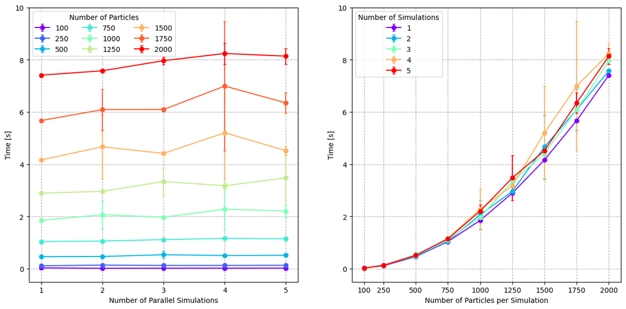

```python
fig, ax = plt.subplots(nrows=1, ncols=2, figsize=(15, 7))

color_part = cm.rainbow(np.linspace(0, 1, mean_time.shape[1]))
color_sim = cm.rainbow(np.linspace(0, 1, mean_time.shape[0]))

for n_part in range(mean_time.shape[1]):

    ax[0].errorbar(x=N_streams_ls,
                 y=mean_time.T[n_part],
                 yerr = std_time.T[n_part],
                 capsize = 2,
                 fmt='-o',
                 color = color_part[n_part],
                 label=f'{N_particles_ls[n_part]}')

ax[0].legend(loc='upper left', ncols=3, fontsize=10, title='Number of Particles')
ax[0].grid(linestyle='--')

ax[0].set_xticks(N_streams_ls)

ax[0].set_ylim(-0.5,10)
ax[0].set_xlabel('Number of Parallel Simulations')
ax[0].set_ylabel('Time [s]')


for n_stream in range(mean_time.shape[0]):

    ax[1].errorbar(x=N_particles_ls,
                 y=mean_time[n_stream],
                 yerr = std_time[n_stream],
                 capsize = 2,
                 fmt='-o', color = color_sim[n_stream],
                 label=f'{N_streams_ls[n_stream]}')

ax[1].legend(loc='upper left', title='Number of Simulations')
ax[1].grid(linestyle='--')

ax[1].set_xticks(N_particles_ls)

ax[1].set_ylim(-0.5,10)
ax[1].set_xlabel('Number of Particles per Simulation')
ax[1].set_ylabel('Time [s]')

fig.savefig('/content/drive/MyDrive/Giacomo/NumbaCuda_Benchamark.png', dpi=300)
```

As can be seen from the plot from the left the implementation can actually parallelise different simulation without any particular performance loss. On the right can be seen that the procedure suffer from the algotrithm implemented for the acceleration estimation that makes the time required grow quadratically as the number of particles increases.